# Cyclistic Bike-Share Case Study: How Does a Bike-Share Navigate Speedy Success?

Eduardo Carrascosa

2/21/2022

# Overview

In this project I will share my findings, including visualizations, key takeaways, and reccomendations from the Cyclistic Bike Share case study project that was my capstone project during Google’s Coursera Data Analytics Certificate. For the purposes of this page I skip the earlier phases of the project and jump straight to sharing my insights and visualizations.

# Data visualizations

### Casual users have longer ride durations on average than members

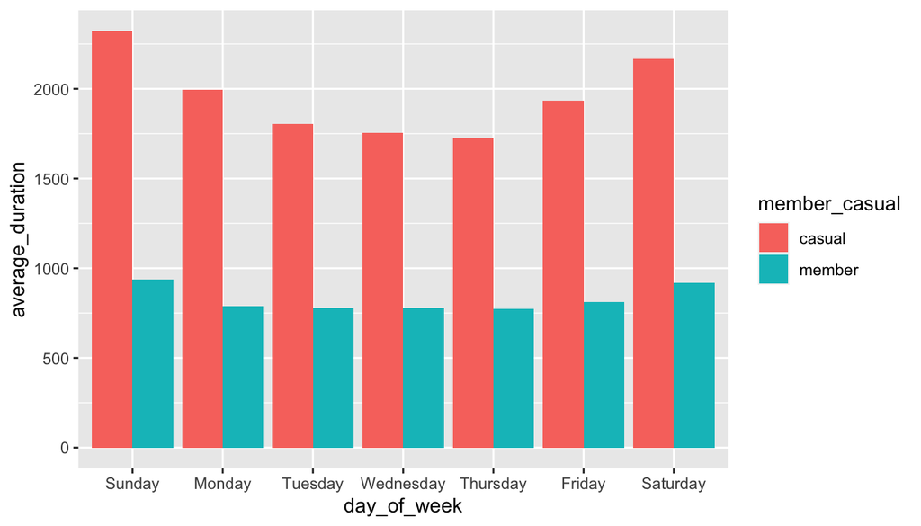

### Casual riders use bikes mostly in the weekends

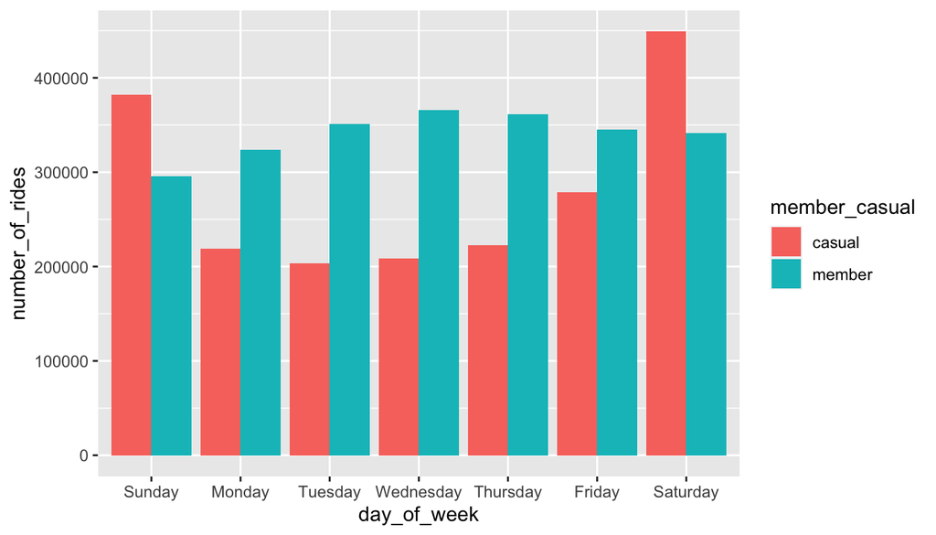

### Streeter Dr & Grand Ave was the most popular bike station

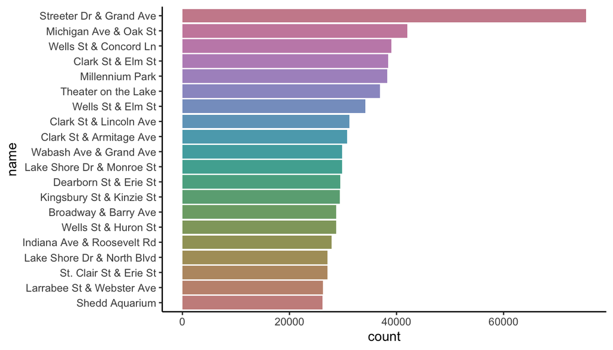

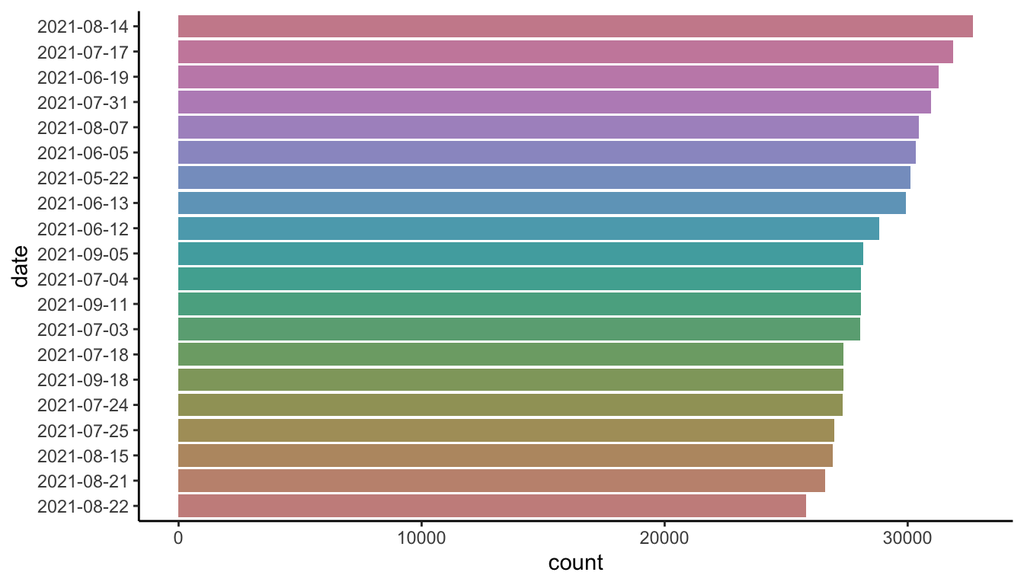

### Docked bikes average the higher duration of the three types of bikes

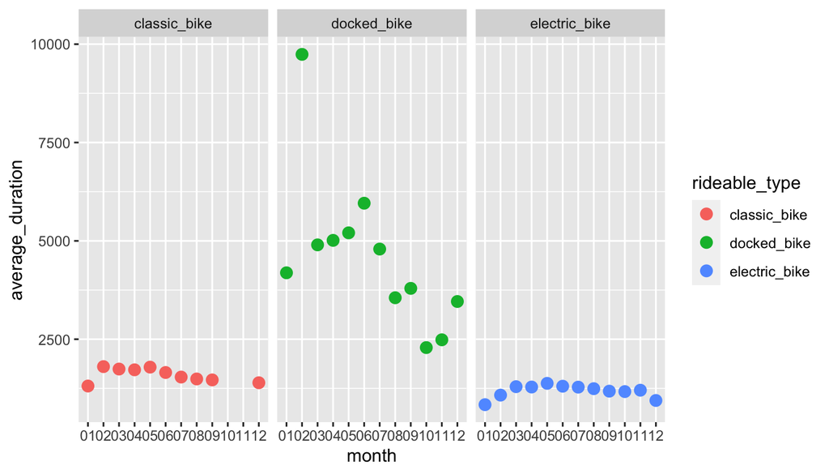